# bio_class_11

caroline iacuaniello

May 9, 2018

### PDB statistics

Import PDB statistics CSV file and calculate percent structures

```r
p <- read.csv("Data Export Summary.csv", row.names = 1)
p
```

```
##                     Proteins Nucleic.Acids Protein.NA.Complex Other  Total
## X-Ray                 117481          1919               6011    10 125421
## NMR                    10708          1243                249     8  12208
## Electron Microscopy     1546            31                542     0   2119
## Other                    215             4                  6    13    238
## Multi Method             116             4                  2     1    123
```

```r
percent <- (p$Total / sum(p$Total))*100
names(percent) <- row.names(p)
percent
```

```
##               X-Ray                 NMR Electron Microscopy
##         89.51673340          8.71321614          1.51239392
##               Other        Multi Method
##          0.16986775          0.08778879
```

```r
## Using Bio3D
library(bio3d)
```

Read in HIV-pr structure

```r
pdb <- read.pdb("1hsg")
```

```
##   Note: Accessing on-line PDB file
```

```r
pdb
```

```
##
##  Call:  read.pdb(file = "1hsg")
##
##    Total Models#: 1
##      Total Atoms#: 1686,  XYZs#: 5058  Chains#: 2  (values: A B)
##
##      Protein Atoms#: 1514  (residues/Calpha atoms#: 198)
##      Nucleic acid Atoms#: 0  (residues/phosphate atoms#: 0)
##
##      Non-protein/nucleic Atoms#: 172  (residues: 128)
##      Non-protein/nucleic resid values: [ HOH (127), MK1 (1) ]
##
##    Protein sequence:
##       PQITLWQRPLVTIKIGGQLKEALLDTGADDTVLEEMSLPGRWKPKMIGGIGGFIKVRQYD
##       QILIEICGHKAIGTVLVGPTPVNIIGRNLLTQIGCTLNFPQITLWQRPLVTIKIGGQLKE
##       ALLDTGADDTVLEEMSLPGRWKPKMIGGIGGFIKVRQYDQILIEICGHKAIGTVLVGPTP
##       VNIIGRNLLTQIGCTLNF
##
## + attr: atom, xyz, seqres, helix, sheet,
##         calpha, remark, call
```

# find the attributes

```r
attributes(pdb)
```

```
## $names
## [1] "atom"   "xyz"    "seqres" "helix"  "sheet"  "calpha" "remark" "call"
##
## $class
## [1] "pdb" "sse"
```

```r
# look at atoms header
head(pdb$atom)
```

```
##   type eleno elety  alt resid chain resno insert      x      y     z o
## 1 ATOM     1     N <NA>   PRO     A     1   <NA> 29.361 39.686 5.862 1
## 2 ATOM     2    CA <NA>   PRO     A     1   <NA> 30.307 38.663 5.319 1
## 3 ATOM     3     C <NA>   PRO     A     1   <NA> 29.760 38.071 4.022 1
## 4 ATOM     4     O <NA>   PRO     A     1   <NA> 28.600 38.302 3.676 1
## 5 ATOM     5    CB <NA>   PRO     A     1   <NA> 30.508 37.541 6.342 1
## 6 ATOM     6    CG <NA>   PRO     A     1   <NA> 29.296 37.591 7.162 1
##       b segid elesy charge
## 1 38.10  <NA>     N   <NA>
## 2 40.62  <NA>     C   <NA>
## 3 42.64  <NA>     C   <NA>
## 4 43.40  <NA>     O   <NA>
## 5 37.87  <NA>     C   <NA>
## 6 38.40  <NA>     C   <NA>
```

```r
# Print a subset of $atom data for the first two atoms
pdb$atom[1:2, c("eleno", "elety", "x","y","z")]
```

```
##   eleno elety      x      y     z
## 1     1     N 29.361 39.686 5.862
## 2     2    CA 30.307 38.663 5.319
```

```r
# Note that individual $atom records can also be accessed like this
pdb$atom$elety[1:2]
```

```
## [1] "N"  "CA"
```

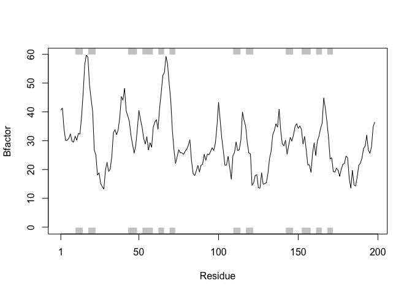

```r
# Which allows us to do the following

plot.bio3d(pdb$atom$b[pdb$calpha], sse=pdb, typ="l", ylab="Bfactor")
```

```r
str(pdb$atom)
```

```
## 'data.frame':    1686 obs. of  16 variables:
##  $ type  : chr  "ATOM" "ATOM" "ATOM" "ATOM" ...
##  $ eleno : int  1 2 3 4 5 6 7 8 9 10 ...
##  $ elety : chr  "N" "CA" "C" "O" ...
##  $ alt   : chr  NA NA NA NA ...
##  $ resid : chr  "PRO" "PRO" "PRO" "PRO" ...
##  $ chain : chr  "A" "A" "A" "A" ...
##  $ resno : int  1 1 1 1 1 1 1 2 2 2 ...
##  $ insert: chr  NA NA NA NA ...
##  $ x     : num  29.4 30.3 29.8 28.6 30.5 ...
##  $ y     : num  39.7 38.7 38.1 38.3 37.5 ...
##  $ z     : num  5.86 5.32 4.02 3.68 6.34 ...
##  $ o     : num  1 1 1 1 1 1 1 1 1 1 ...
##  $ b     : num  38.1 40.6 42.6 43.4 37.9 ...
##  $ segid : chr  NA NA NA NA ...
##  $ elesy : chr  "N" "C" "C" "O" ...
##  $ charge: chr  NA NA NA NA ...
```

# Print a summary of the coordinate data in $xyz

```r
pdb$xyz
```

```
##
##    Total Frames#: 1
##    Total XYZs#:   5058,  (Atoms#:  1686)
##
##     [1]  29.361  39.686  5.862  <...>  30.112  17.912  -4.791  [5058]
##
## + attr: Matrix DIM = 1 x 5058
```

# Examine the row and column dimensions

```r
dim(pdb$xyz)
```

```
## [1]    1 5058
```

# Print coordinates for the first two atom

```r
pdb$xyz[ 1, atom2xyz(1:2) ]
```

```
## [1] 29.361 39.686  5.862 30.307 38.663  5.319
```

# Select all C-alpha atoms (return their indices)

```r
ca.inds <- atom.select(pdb, "calpha")
ca.inds
```

```
##
##  Call:  atom.select.pdb(pdb = pdb, string = "calpha")
##
##    Atom Indices#: 198  ($atom)
##    XYZ  Indices#: 594  ($xyz)
##
## + attr: atom, xyz, call
```

Q8. Use the Bio3D write.pdb() function to write out a protein only PDB file for viewing in VMD. Also write out a second separate PDB file for the ligand with residue name MK1 HINT: In Bio3D you can use the trim.pdb() function together with the pub object and your atom selections such as atom.select(pdb, ’protein’) for the fist file and atom.select(pdb, ‘ligand’) for the second.

```r
inds.ligand <- atom.select(pdb, "ligand")
inds.protein <- atom.select(pdb, "protein")
inds.protein
```

```
##
##  Call:  atom.select.pdb(pdb = pdb, string = "protein")
##
##    Atom Indices#: 1514  ($atom)
##    XYZ  Indices#: 4542  ($xyz)
##
## + attr: atom, xyz, call
```

# check what have

```r
pdb$atom[inds.ligand$atom,]
```

```
##        type eleno elety  alt resid chain resno insert      x      y      z
## 1515 HETATM  1517    N1 <NA>   MK1     B   902   <NA>  9.280 23.763  3.004
## 1516 HETATM  1518    C1 <NA>   MK1     B   902   <NA>  9.498 23.983  4.459
## 1517 HETATM  1519    C2 <NA>   MK1     B   902   <NA> 10.591 24.905  4.962
## 1518 HETATM  1520    C3 <NA>   MK1     B   902   <NA> 10.591 24.864  6.466
## 1519 HETATM  1521    O1 <NA>   MK1     B   902   <NA> 10.937 23.849  7.057
## 1520 HETATM  1522    N2 <NA>   MK1     B   902   <NA> 10.193 25.953  7.094
## 1521 HETATM  1523    C4 <NA>   MK1     B   902   <NA> 10.145 26.250  8.490
## 1522 HETATM  1524    C5 <NA>   MK1     B   902   <NA>  9.379 27.577  8.641
## 1523 HETATM  1525    C6 <NA>   MK1     B   902   <NA> 11.398 26.347  9.074
## 1524 HETATM  1526    C7 <NA>   MK1     B   902   <NA>  9.364 25.283  9.268
## 1525 HETATM  1527    N3 <NA>   MK1     B   902   <NA> 11.819 24.282  4.355
## 1526 HETATM  1528    C8 <NA>   MK1     B   902   <NA> 11.753 23.776  2.961
## 1527 HETATM  1529    C9 <NA>   MK1     B   902   <NA> 10.440 23.182  2.493
## 1528 HETATM  1530   C10 <NA>   MK1     B   902   <NA> 13.083 24.963  4.552
```

[output cut: 77 more lines]

```r
pdb$atom[inds.protein$atom,]
```

```
##      type eleno elety  alt resid chain resno insert      x      y       z
## 1    ATOM     1     N <NA>   PRO     A     1   <NA> 29.361 39.686   5.862
## 2    ATOM     2    CA <NA>   PRO     A     1   <NA> 30.307 38.663   5.319
## 3    ATOM     3     C <NA>   PRO     A     1   <NA> 29.760 38.071   4.022
## 4    ATOM     4     O <NA>   PRO     A     1   <NA> 28.600 38.302   3.676
## 5    ATOM     5    CB <NA>   PRO     A     1   <NA> 30.508 37.541   6.342
## 6    ATOM     6    CG <NA>   PRO     A     1   <NA> 29.296 37.591   7.162
## 7    ATOM     7    CD <NA>   PRO     A     1   <NA> 28.778 39.015   7.019
## 8    ATOM     8     N <NA>   GLN     A     2   <NA> 30.607 37.334   3.305
## 9    ATOM     9    CA <NA>   GLN     A     2   <NA> 30.158 36.492   2.199
## 10   ATOM    10     C <NA>   GLN     A     2   <NA> 30.298 35.041   2.643
## 11   ATOM    11     O <NA>   GLN     A     2   <NA> 31.401 34.494   2.763
## 12   ATOM    12    CB <NA>   GLN     A     2   <NA> 30.970 36.738   0.926
## 13   ATOM    13    CG <NA>   GLN     A     2   <NA> 30.625 35.783  -0.201
## 14   ATOM    14    CD <NA>   GLN     A     2   <NA> 31.184 36.217  -1.549
```

[output cut: 3015 more lines]

# what want is to output new pdb file

```r
pdb.ligand <- trim.pdb(pdb, inds=inds.ligand)
pdb.protein <- trim.pdb(pdb, inds=inds.protein)
pdb.ligand
```

```
##
##  Call:  trim.pdb(pdb = pdb, inds = inds.ligand)
##
##    Total Models#: 1
##      Total Atoms#: 45,  XYZs#: 135  Chains#: 1  (values: B)
##
##      Protein Atoms#: 0  (residues/Calpha atoms#: 0)
##      Nucleic acid Atoms#: 0  (residues/phosphate atoms#: 0)
##
##      Non-protein/nucleic Atoms#: 45  (residues: 1)
##      Non-protein/nucleic resid values: [ MK1 (1) ]
##
## + attr: atom, helix, sheet, seqres, xyz,
##         calpha, call
```

```r
write.pdb(pdb.ligand, file="1hsg_ligand.pdb")
write.pdb(pdb.protein, file="1hsg_protein.pdb")
```

# Download some example PDB files

```r
ids <- c("1TND_B","1AGR_A","1TAG_A","1GG2_A","1KJY_A","4G5Q_A")
files <- get.pdb(ids, split = TRUE)
```

# Extract and align the chains we are interested in

```r
pdbs <- pdbaln(files, fit = TRUE)
```

```
## Reading PDB files:
## ./split_chain/1TND_B.pdb
## ./split_chain/1AGR_A.pdb
## ./split_chain/1TAG_A.pdb
## ./split_chain/1GG2_A.pdb
## ./split_chain/1KJY_A.pdb
## ./split_chain/4G5Q_A.pdb
## .....   PDB has ALT records, taking A only, rm.alt=TRUE
## .
##
## Extracting sequences
##
## pdb/seq: 1   name: ./split_chain/1TND_B.pdb
## pdb/seq: 2   name: ./split_chain/1AGR_A.pdb
## pdb/seq: 3   name: ./split_chain/1TAG_A.pdb
## pdb/seq: 4   name: ./split_chain/1GG2_A.pdb
## pdb/seq: 5   name: ./split_chain/1KJY_A.pdb
## pdb/seq: 6   name: ./split_chain/4G5Q_A.pdb
##    PDB has ALT records, taking A only, rm.alt=TRUE
```

# Print to screen a summary of the ‘pdbs’ object

```r
pdbs
```

```
##                                1        .         .         .         .         50
## [Truncated_Name:1]1TND_B.pdb   --------------------------ARTVKLLLLGAGESGKSTIVKQMK
## [Truncated_Name:2]1AGR_A.pdb   LSAEDKAAVERSKMIDRNLREDGEKAAREVKLLLLGAGESGKSTIVKQMK
## [Truncated_Name:3]1TAG_A.pdb   --------------------------ARTVKLLLLGAGESGKSTIVKQMK
## [Truncated_Name:4]1GG2_A.pdb   LSAEDKAAVERSKMIDRNLREDGEKAAREVKLLLLGAGESGKSTIVKQMK
## [Truncated_Name:5]1KJY_A.pdb   -------------------------GAREVKLLLLGAGESGKSTIVKQMK
## [Truncated_Name:6]4G5Q_A.pdb   --------------------------AREVKLLLLGAGESGKSTIVKQMK
##                                                          ** *********************
##                                1        .         .         .         .         50
##
##                               51        .         .         .         .         100
## [Truncated_Name:1]1TND_B.pdb   IIHQDGYSLEECLEFIAIIYGNTLQSILAIVRAMTTLNIQYGDSARQDDA
## [Truncated_Name:2]1AGR_A.pdb   IIHEAGYSEEECKQYKAVVYSNTIQSIIAIIRAMGRLKIDFGDAARADDA
## [Truncated_Name:3]1TAG_A.pdb   IIHQDGYSLEECLEFIAIIYGNTLQSILAIVRAMTTLNIQYGDSARQDDA
## [Truncated_Name:4]1GG2_A.pdb   IIHEAGYSEEECKQYKAVVYSNTIQSIIAIIRAMGRLKIDFGDAARADDA
## [Truncated_Name:5]1KJY_A.pdb   IIHEAGYSEEECKQYKAVVYSNTIQSIIAIIRAMGRLKIDFGDSARADDA
## [Truncated_Name:6]4G5Q_A.pdb   IIHEAGYSEEECKQYKAVVYSNTIQSIIAIIRAMGRLKIDFGDSARADDA
##                                ***  *** ***  ^ *^^* **^***^**^***  * * ^** ** ***
##                               51        .         .         .         .         100
##
##                              101        .         .         .         .         150
## [Truncated_Name:1]1TND_B.pdb   RKLMHMADTIEEGTMPKEMSDIIQRLWKDSGIQACFDRASEYQLNDSAGY
## [Truncated_Name:2]1AGR_A.pdb   RQLFVLAGAAEEGFMTAELAGVIKRLWKDSGVQACFNRSREYQLNDSAAY
## [Truncated_Name:3]1TAG_A.pdb   RKLMHMADTIEEGTMPKEMSDIIQRLWKDSGIQACFDRASEYQLNDSAGY
## [Truncated_Name:4]1GG2_A.pdb   RQLFVLAGAAEEGFMTAELAGVIKRLWKDSGVQACFNRSREYQLNDSAAY
## [Truncated_Name:5]1KJY_A.pdb   RQLFVLAGAAEEGFMTAELAGVIKRLWKDSGVQACFNRSREYQLNDSAAY
## [Truncated_Name:6]4G5Q_A.pdb   RQLFVLAGAAEEGFMTAELAGVIKRLWKDSGVQACFNRSREYQLNDSAAY
##                                * *  ^*   *** *  *^  ^* *******^**** *  ********^*
##                              101        .         .         .         .         150
##
##                              151        .         .         .         .         200
## [Truncated_Name:1]1TND_B.pdb   YLSDLERLVTPGYVPTEQDVLRSRVKTTGIIETQFSFKDLNFRMFDVGGQ
## [Truncated_Name:2]1AGR_A.pdb   YLNDLDRIAQPNYIPTQQDVLRTRVKTTGIVETHFTFKDLHFKMFDVGGQ
## [Truncated_Name:3]1TAG_A.pdb   YLSDLERLVTPGYVPTEQDVLRSRVKTTGIIETQFSFKDLNFRMFDVGGQ
## [Truncated_Name:4]1GG2_A.pdb   YLNDLDRIAQPNYIPTQQDVLRTRVKTTGIVETHFTFKDLHFKMFDVGAQ
## [Truncated_Name:5]1KJY_A.pdb   YLNDLDRIAQPNYIPTQQDVLRTRVKTTGIVETHFTFKDLHFKMFDVGGQ
## [Truncated_Name:6]4G5Q_A.pdb   YLNDLDRIAQPNYIPTQQDVLRTRVKTTGIVETHFTFKDLHFKMFDVGGQ
##                                ** **^*^  * *^** *****^*******^** *^**** *^*****^*
##                              151        .         .         .         .         200
##
```

[output cut: 25 more lines]

```
## [Truncated_Name:5]1KJY_A.pdb   CQFEDLNKRKDTKEIYTHFTCATDTKNVQFVFDAVTDVIIKNNLK-----
## [Truncated_Name:6]4G5Q_A.pdb   CQFEDLNKRKDTKEIYTHFTCATDTKNVQFVFDAVTDVIIKNNLKD----
##                                 ** ^** *^* ****^* ****** ** ********^**
##                              301        .         .         .         .         350
##
## Call:
##   pdbaln(files = files, fit = TRUE)
##
## Class:
##   pdbs, fasta
##
## Alignment dimensions:
##   6 sequence rows; 350 position columns (314 non-gap, 36 gap)
##
## + attr: xyz, resno, b, chain, id, ali, resid, sse, call
```

Here the returned object is of class pdbs. Note that it contains a xyz numeric matrix of aligned C-alpha coordinates, a ali matrix of aligned residues, and a resno matrix of aligned residue numbers (see the list of associated attributes (+ attr)). These attirbutes can be accessed using the common $ syntax in R. E.g. use pdbs$ali to access the alignment. To access the first few rows of the alignment matrix we use standard subsetting syntax for matrices in R:

```r
# Access the first 5 rows, and 8 columns
pdbs$ali[1:5, 1:8]
```

```
##                          [,1] [,2] [,3] [,4] [,5] [,6] [,7] [,8]
## ./split_chain/1TND_B.pdb "-"  "-"  "-"  "-"  "-"  "-"  "-"  "-"
## ./split_chain/1AGR_A.pdb "L"  "S"  "A"  "E"  "D"  "K"  "A"  "A"
## ./split_chain/1TAG_A.pdb "-"  "-"  "-"  "-"  "-"  "-"  "-"  "-"
## ./split_chain/1GG2_A.pdb "L"  "S"  "A"  "E"  "D"  "K"  "A"  "A"
## ./split_chain/1KJY_A.pdb "-"  "-"  "-"  "-"  "-"  "-"  "-"  "-"
```

```r
# Associated residues numbers
pdbs$resno[1:5, 1:8]
```

```
##                          [,1] [,2] [,3] [,4] [,5] [,6] [,7] [,8]
## ./split_chain/1TND_B.pdb   NA   NA   NA   NA   NA   NA   NA   NA
## ./split_chain/1AGR_A.pdb    5    6    7    8    9   10   11   12
## ./split_chain/1TAG_A.pdb   NA   NA   NA   NA   NA   NA   NA   NA
## ./split_chain/1GG2_A.pdb    5    6    7    8    9   10   11   12
## ./split_chain/1KJY_A.pdb   NA   NA   NA   NA   NA   NA   NA   NA
```

## skip to section 5

5.1 Search and retrieve Adenylate kinase structures Below we perform a blast search of the PDB database to identify related structures to our query Adenylate kinase sequence. In this particular example we use function get.seq() to fetch the query sequence for chain A of the PDB ID 1AKE and use this as input to blast.pdb(). Note that get.seq() would also allow the corresponding UniProt identifier.

```r
# fetch sequence
aa <- get.seq("1ake_A")
aa
```

```
##              1        .         .         .         .         .         60
## pdb|1AKE|A   MRIILLGAPGAGKGTQAQFIMEKYGIPQISTGDMLRAAVKSGSELGKQAKDIMDAGKLVT
##              1        .         .         .         .         .         60
##
##             61        .         .         .         .         .         120
## pdb|1AKE|A   DELVIALVKERIAQEDCRNGFLLDGFPRTIPQADAMKEAGINVDYVLEFDVPDELIVDRI
##             61        .         .         .         .         .         120
##
##            121        .         .         .         .         .         180
## pdb|1AKE|A   VGRRVHAPSGRVYHVKFNPPKVEGKDDVTGEELTTRKDDQEETVRKRLVEYHQMTAPLIG
##            121        .         .         .         .         .         180
##
##            181        .         .         .   214
## pdb|1AKE|A   YYSKEAEAGNTKYAKVDGTKPVAEVRADLEKILG
##            181        .         .         .   214
##
## Call:
##   read.fasta(file = outfile)
##
## Class:
##   fasta
##
## Alignment dimensions:
##   1 sequence rows; 214 position columns (214 non-gap, 0 gap)
##
## + attr: id, ali, call
```

```r
# Blast or hmmer search
b <- blast.pdb(aa)
```

```
##  Searching ... please wait (updates every 5 seconds) RID = F6ZFAVDK014
##  .
##  Reporting 90 hits
```

```
##   * Possible cutoff values:    198 -3
##             Yielding Nhits:    12 90
##
##   * Chosen cutoff value of:    198
##             Yielding Nhits:    12
```

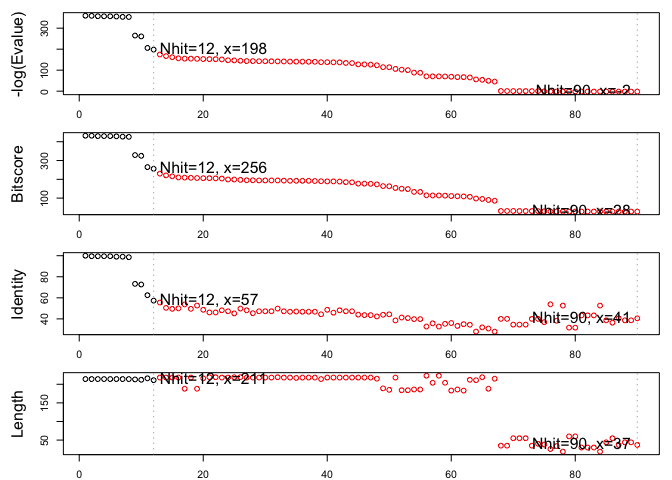

```r
# Plot a summary of search results
hits <- plot(b)
```

```r
# can set cutoff= any number to get more hits
```

```r
head(hits$pdb.id)
```

```
## [1] "1AKE_A" "4X8M_A" "4X8H_A" "3HPR_A" "1E4V_A" "5EJE_A"
```

```r
hits
```

```
## $hits
##    pdb.id   acc      group
## 1  "1AKE_A" "1AKE_A" "1"
## 2  "4X8M_A" "4X8M_A" "1"
## 3  "4X8H_A" "4X8H_A" "1"
## 4  "3HPR_A" "3HPR_A" "1"
## 5  "1E4V_A" "1E4V_A" "1"
## 6  "5EJE_A" "5EJE_A" "1"
## 7  "1E4Y_A" "1E4Y_A" "1"
## 8  "3X2S_A" "3X2S_A" "1"
## 9  "4K46_A" "4K46_A" "1"
## 10 "4NP6_A" "4NP6_A" "1"
## 11 "3GMT_A" "3GMT_A" "1"
## 12 "4PZL_A" "4PZL_A" "1"
##
```

[output cut: 21 more lines]

fetch pdbs, and align,

```r
# fetch
files <- get.pdb(hits$pdb.id, path = "pdbs", split = TRUE, gzip =
TRUE)
# Align structures
pdbs <- pdbaln(files)
```

```
## Reading PDB files:
## pdbs/split_chain/1AKE_A.pdb
## pdbs/split_chain/4X8M_A.pdb
## pdbs/split_chain/4X8H_A.pdb
## pdbs/split_chain/3HPR_A.pdb
## pdbs/split_chain/1E4V_A.pdb
## pdbs/split_chain/5EJE_A.pdb
## pdbs/split_chain/1E4Y_A.pdb
## pdbs/split_chain/3X2S_A.pdb
## pdbs/split_chain/4K46_A.pdb
## pdbs/split_chain/4NP6_A.pdb
## pdbs/split_chain/3GMT_A.pdb
## pdbs/split_chain/4PZL_A.pdb
##    PDB has ALT records, taking A only, rm.alt=TRUE
## ...   PDB has ALT records, taking A only, rm.alt=TRUE
## ..   PDB has ALT records, taking A only, rm.alt=TRUE
## ...   PDB has ALT records, taking A only, rm.alt=TRUE
## ....
##
## Extracting sequences
##
## pdb/seq: 1   name: pdbs/split_chain/1AKE_A.pdb
##    PDB has ALT records, taking A only, rm.alt=TRUE
## pdb/seq: 2   name: pdbs/split_chain/4X8M_A.pdb
## pdb/seq: 3   name: pdbs/split_chain/4X8H_A.pdb
## pdb/seq: 4   name: pdbs/split_chain/3HPR_A.pdb
##    PDB has ALT records, taking A only, rm.alt=TRUE
## pdb/seq: 5   name: pdbs/split_chain/1E4V_A.pdb
## pdb/seq: 6   name: pdbs/split_chain/5EJE_A.pdb
##    PDB has ALT records, taking A only, rm.alt=TRUE
## pdb/seq: 7   name: pdbs/split_chain/1E4Y_A.pdb
## pdb/seq: 8   name: pdbs/split_chain/3X2S_A.pdb
## pdb/seq: 9   name: pdbs/split_chain/4K46_A.pdb
##    PDB has ALT records, taking A only, rm.alt=TRUE
## pdb/seq: 10   name: pdbs/split_chain/4NP6_A.pdb
## pdb/seq: 11   name: pdbs/split_chain/3GMT_A.pdb
## pdb/seq: 12   name: pdbs/split_chain/4PZL_A.pdb
```

```r
# Vector containing PDB codes
ids <- basename.pdb(pdbs$id)
```

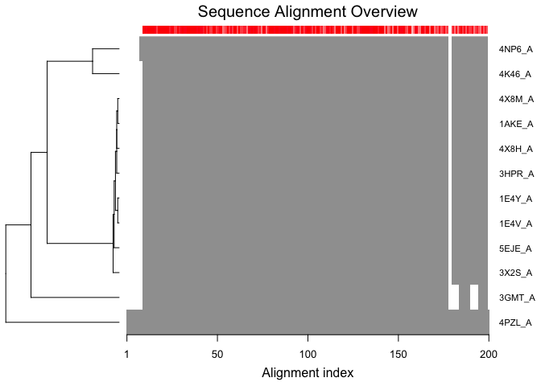

```r
# Draw schematic alignment
plot(pdbs, labels=ids)
```

```r
# find invariant core
core <- core.find(pdbs)
```

```
##  core size 203 of 204  vol = 968.435
##  core size 202 of 204  vol = 929.83
##  core size 201 of 204  vol = 896.725
##  core size 200 of 204  vol = 870.563
##  core size 199 of 204  vol = 842.313
##  core size 198 of 204  vol = 818.551
##  core size 197 of 204  vol = 789.425
##  core size 196 of 204  vol = 758.485
##  core size 195 of 204  vol = 733.831
##  core size 194 of 204  vol = 707.91
##  core size 193 of 204  vol = 680.579
##  core size 192 of 204  vol = 652.935
##  core size 191 of 204  vol = 627.823
##  core size 190 of 204  vol = 606.714
##  core size 189 of 204  vol = 589.891
##  core size 188 of 204  vol = 568.49
##  core size 187 of 204  vol = 548.134
##  core size 186 of 204  vol = 525.13
##  core size 185 of 204  vol = 503.515
##  core size 184 of 204  vol = 481.666
##  core size 183 of 204  vol = 461.273
##  core size 182 of 204  vol = 440.71
##  core size 181 of 204  vol = 417.769
##  core size 180 of 204  vol = 397.549
##  core size 179 of 204  vol = 379.747
##  core size 178 of 204  vol = 363.953
##  core size 177 of 204  vol = 350.568
##  core size 176 of 204  vol = 335.769
##  core size 175 of 204  vol = 321.06
##  core size 174 of 204  vol = 308.453
##  core size 173 of 204  vol = 297.263
##  core size 172 of 204  vol = 284.751
##  core size 171 of 204  vol = 273.174
##  core size 170 of 204  vol = 265.125
##  core size 169 of 204  vol = 254.902
##  core size 168 of 204  vol = 241.569
##  core size 167 of 204  vol = 231.662
##  core size 166 of 204  vol = 221.509
##  core size 165 of 204  vol = 216.205
##  core size 164 of 204  vol = 205.327
```

[output cut: 118 more lines]

```
##  core size 45 of 204  vol = 1.238
##  core size 44 of 204  vol = 1.155
##  core size 43 of 204  vol = 1.07
##  core size 42 of 204  vol = 0.967
##  core size 41 of 204  vol = 0.906
##  core size 40 of 204  vol = 0.845
##  core size 39 of 204  vol = 0.792
##  core size 38 of 204  vol = 0.744
##  core size 37 of 204  vol = 0.695
##  core size 36 of 204  vol = 0.648
##  core size 35 of 204  vol = 0.596
##  core size 34 of 204  vol = 0.553
##  core size 33 of 204  vol = 0.523
##  core size 32 of 204  vol = 0.496
##  FINISHED: Min vol ( 0.5 ) reached
```

```r
# superimpose all structures to core
pdbs$xyz = pdbfit(pdbs, core)
# Perform PCA
pc.xray <- pca(pdbs)
```

```r
# Calculate RMSD
rd <- rmsd(pdbs)
```

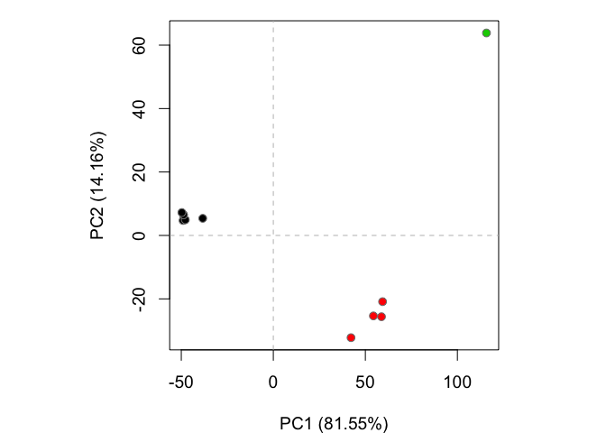

```r
# Structure-based clustering
hc.rd <- hclust(dist(rd))
grps.rd <- cutree(hc.rd, k=3)
plot(pc.xray, 1:2, col="grey50", bg=grps.rd, pch=21, cex=1)
```

```r
# Visualize first principal component
mktrj(pc.xray, pc=1, file="pc_1.pdb")
```

```r
#view in r with new code
# download new
```